# Monte Carlo

To compute the pvalues I tried various things but what seems to work best is the following approach. For a given observed test statistic $T$ and number of simulations $B$:

- Step 1: Let $k = 1$
- Step 2: simulate two uniform random vectors:
  $$\begin{equation}
  \begin{aligned}
  X^{\star}_i &\sim \mathcal{U}(0,1)\\
  Y^{\star}_j &\sim \mathcal{U}(0,1),
  \end{aligned}
  \end{equation}$$
  where $i= 1,...,m-1$ and $j = 1,...,n$.
- Step 3: compute test statistic based on the spacings obtained on the simulated samples $X^{\star}$ and $Y^{\star}$. Denote this statistic $T^{(k)}$.
- Step 4: if $k < B$, let $k = k + 1$ and go to step 2; otherwise go to Step 5.
- Step 5: compute estimated pvalues:
  $$\begin{equation}
  \widehat{\text{pval}} = \frac{1}{B} \sum_{b = 1}^B I_{T \leq T^{(b)}}
  \end{equation}$$
  where $I$ denote the indicator function.

Here is a simple simulation to illustrate the performance of the approximation.

```r
library(circTest)
set.seed(17)
X = 360*runif(7)
Y = 360*runif(8)
exact_test = circular_test(X, Y, test = "dixon")
(exact_pval = mean(exact_test$stat <= exact_test$cv$dist))
```

```
## [1] 0.3885004
```

By simulations with $B = 10^4$ we obtain:

```r
mc_test = circular_test(X, Y, test = "dixon", type = "mc")
(mc_pval = mean(mc_test$stat <= mc_test$mc$dist))
```

```
## [1] 0.3887
```

Let’s repeat this $10^3$ times with $B = 10^3$ and $B = 10^4$…

```r
H = 10^3
pval = matrix(NA, H, 2)
B = c(10^3, 10^4)

for (j in 1:length(B)){
  for (i in 1:H){
  mc_test = circular_test(X, Y, test = "dixon", type = "mc", seed = i, B = B[j])
  pval[i,j] = mean(mc_test$stat <= mc_test$mc$dist)
  }
}
```

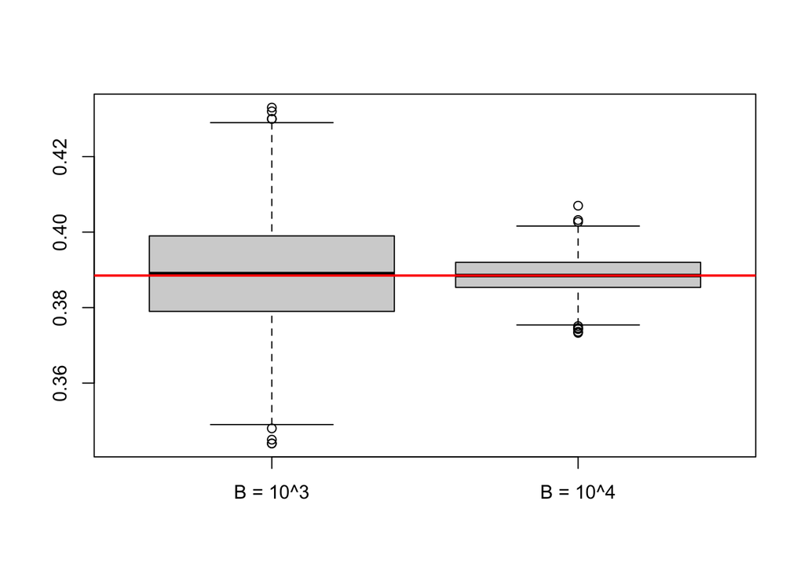

```r
boxplot(pval, col = "lightgrey", names = c("B = 10^3", "B = 10^4"))
abline(h = exact_pval, col = 2, lwd = 2)
```

We can also obtain an estimation of precision of the obtained p-value by non-parametric bootstrap. For example, we could do:

```r
pval_boot = function(out, B = 10^3, alpha = 0.05){
  pval = rep(NA, B)
  n = length(out$mc$dist)
  for (i in 1:B){
    dist_star = out$mc$dist[sample(1:n, replace = TRUE)]
    pval[i] = mean(out$stat <= dist_star)
  }
  list(sd = sd(pval), quant = as.numeric(quantile(pval, probs = c(alpha/2, 1 - alpha/2))))
}
```

Using our previous example, we obtain:

```r
pval_boot(mc_test)
```

```
## $sd
## [1] 0.004938784
##
## $quant
## [1] 0.3785975 0.3977000
```

which seems reasonable given the boxplot presented above.

Finally, we study the coverage properties using $10^3$ simulations of this method for 95% confidence intervals with $B = 10^4$.

```r
H = 10^3
test = rep(NA, H)
for (i in 1:H){
  mc_test = circular_test(X, Y, test = "dixon", type = "mc", seed = i)
  ci = pval_boot(mc_test)$quant
  test[i] = (ci[1] < exact_pval) && (ci[2] > exact_pval)
}
(emp_cov = mean(test))
```

```
## [1] 0.951
```

Therefore, we obtain an empirical coverage of 95.1%.